# Writing Reports with R Markdown

Inna Smirnova

2023-03-29

This report is created for UN. Testing associations between GDP and CO2 emissions.

```r
#setwd("C:/Users/innas/Desktop/un-report")
gapminder_1997 <- read_csv("Desktop/un-report/data/gapminder_1997.csv")
```

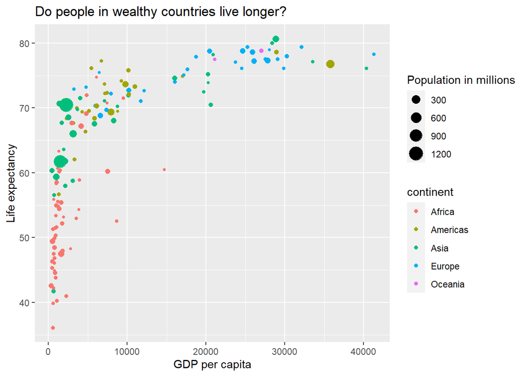

```r
nCountries <- gapminder_1997 %>%
  select(country) %>%
  n_distinct()

minGDP <- gapminder_1997 %>%
  summarise(round(min(gdpPercap))) %>%
  pull() # extracts column

maxGDP <- gapminder_1997 %>%
  summarise(round(max(gdpPercap))) %>%
  pull() # extracts column
```

The above plot shows the relationship between GDP per capita and life expectancy for a total of 142 countries. For this set, economic wealth ranged from a minimum of 312 USD to a maximum of 41283 USD per capita.

| Summary of Data |  |
| --- | --- |
| Number of countries | 142 |
| Minimum GDP per capita | 312 |
| Maximum GDP per capita | 41283 |

```r
library(knitr)

gapminder_1997 %>%
  filter(continent=="Oceania") %>%
  kable()
```

| country | pop | continent | lifeExp | gdpPercap |
| --- | --- | --- | --- | --- |
| Australia | 18565243 | Oceania | 78.83 | 26997.94 |
| New Zealand | 3676187 | Oceania | 77.55 | 21050.41 |

# Header 1

## Header 2

### My third header

Exercise: R Markdown Syntax * create a bullet point list with 3 items * 1st item=name of your fav programming language in bold * 2nd item=most useful function in italics * 3rd item=learning goal in bold italics * turn your bullet point list into a numbered list * create a 4th list item=markdown help list name and hyperlink

- My bullet point list “My programming journey”
  - My favorite programming language is **Python**
  - Most useful Python function I learnt was *pickle*
  - My learning goal is to *practice more and more Python:)*

My list:

- **R**
- *mutate()*
- *regression analysis in Python*
- My numbered list “My programming journey”
  1. My favorite programming language is **Python**
  2. Most useful Python function I learnt was *pickle*
  3. My learning goal is to *practice more and more Python:)*
  4. Markdown helplist **“Markdown Basics”** is available at https://rmarkdown.rstudio.com/authoring_basics.html

My list:

1. **R** # this creates correct numbers automatically
2. *mutate()*
3. *regression analysis in Python*
4. https://www.markdownguide.org/cheat-sheet/